# NumPy_array_01

To begin, a basic import of NumPy is made to make it available. Generally, NumPy is imported and given the notation 'np'. This isn't a rule, but if followed, it will just be easier for you to repurpose code obtained elsewhere.

```python
import numpy as np
```

We can construct a basic array using some very simple methods. A small 2D array of sequential values can be constructed using 'arange' which produces numbers of a certain type in a certain range.

**Definition :** arange([start,] stop[, step,], dtype=None) **Type :** Function of numpy.core.multiarray module

```python
a = np.arange(9).reshape(3, 3)
print("Array ... \n{}".format(a))
```

```
Array ...
[[0 1 2]
 [3 4 5]
 [6 7 8]]
```

A slightly more complex example entails constructing an array or random integers within a specified range of values with a prescribe array shape. The random in NumPy is exploited and the Mersenne Twister random number generator. There are a variety of distributions that can be created, and in this example random integers in the range 0 up to 10 are created with a shape of 9 rows and 12 columns. RandomState is used to ensure that the same pattern is generated each time the array is created so that there is a random generations only once, then the values are fixed.

```python
# ---- construct a repeatable array of 2D integers with a shape of 9 rows by 12 columns. ----
import numpy as np
a = np.random.mtrand.RandomState(1).randint(0, 10, size=(9, 12))
print("2D array ... {} rows {} cols\n{}".format(*a.shape, a))
```

```
2D array ... 9 rows 12 cols
[[5 8 9 5 0 0 1 7 6 9 2 4]
 [5 2 4 2 4 7 7 9 1 7 0 6]
 [9 9 7 6 9 1 0 1 8 8 3 9]
 [8 7 3 6 5 1 9 3 4 8 1 4]
 [0 3 9 2 0 4 9 2 7 7 9 8]
 [6 9 3 7 7 4 5 9 3 6 8 0]
 [2 7 7 9 7 3 0 8 7 7 1 1]
 [3 0 8 6 4 5 6 2 5 7 8 4]
 [4 7 7 4 9 0 2 0 7 1 7 9]]
```

We can make a 'map' from a 2D array using MatPlotLib. Two variants are produced by reshaping 256 sequential integers into a 16x16 array (map). An RGB image is produced from the 3 'bands' of information and 'stacked together

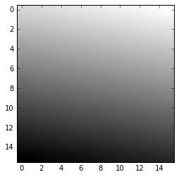

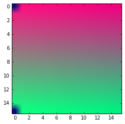

```python
# num_92 gray scale image from rgb
def num_92():
    """num_92... gray-scale image from rgb
    :Essentially gray = 0.2989 * r + 0.5870 * g + 0.1140 * b
    : http://stackoverflow.com/questions/12201577/how-can-i-convert
    :       -an-rgb-image-into-grayscale-in-python
    : https://en.m.wikipedia.org/wiki/Grayscale#Converting_color_to_grayscale
    : see https://en.m.wikipedia.org/wiki/HSL_and_HSV
    """
    import numpy as np
    import matplotlib.pyplot as plt
    a = np.arange(256).reshape(16, 16)
    b = a[::-1]
    c = np.ones_like(a)*128
    rgb = np.dstack((a, b, c))
    gray = np.dot(rgb[..., :3], [0.2989, 0.5870, 0.1140])
    plt.imshow(gray, cmap=plt.get_cmap('gray'))
    plt.show()
    plt.imshow(rgb, cmap=plt.get_cmap('spectral'))
    plt.show()

num_92() # produce the gray image
```

That is just some of the basics you can do with the packages that are available to you through numpy and ArcMap and ArcGIS Pro.